# ESTATÍSTICA DESCRITIVA

## QUESTÃO ED1

Para fins de vistoria ambiental, a concentração de monóxido de carbono (CO, mg/m3) foi medida em quatro chaminés. Os dados obtidos são apresentados a seguir,

| Cham1 | Cham2 | Cham3 | Cham4 |
| --- | --- | --- | --- |
| 40.5 | 41.64 | 35.0 | 44.5 |
| 41.5 | 58.36 | 37.0 | 45.0 |
| 42.5 | 42.29 | 42.0 | 45.5 |
| 43.5 | 57.71 | 53.9 | 46.0 |
| 44.5 | 42.93 | 53.0 | 46.5 |
| 45.5 | 57.07 | 50.6 | 47.0 |
| 46.5 | 43.57 | 50.5 | 47.5 |
| 47.5 | 56.43 | 53.8 | 48.0 |
| 48.5 | 44.21 | 52.5 | 48.5 |
| 49.5 | 55.79 | 53.6 | 49.0 |
| 50.5 | 44.86 | 50.4 | 49.5 |
| 51.5 | 55.14 | 52.2 | 50.0 |
| 52.5 | 45.50 | 52.7 | 50.5 |
| 53.5 | 54.50 | 52.4 | 51.0 |
| 54.5 | 46.14 | 52.7 | 51.5 |
| 55.5 | 53.86 | 51.4 | 52.0 |
| 59.5 | 46.79 | 53.8 | 52.5 |

[output not shown]

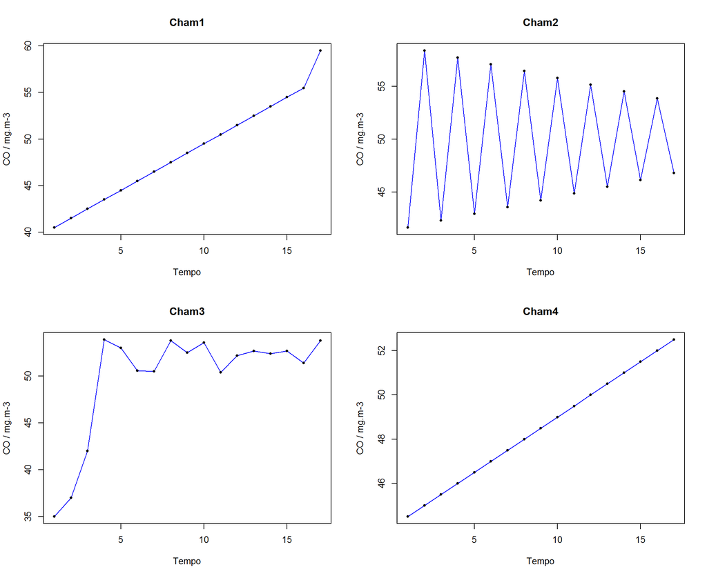

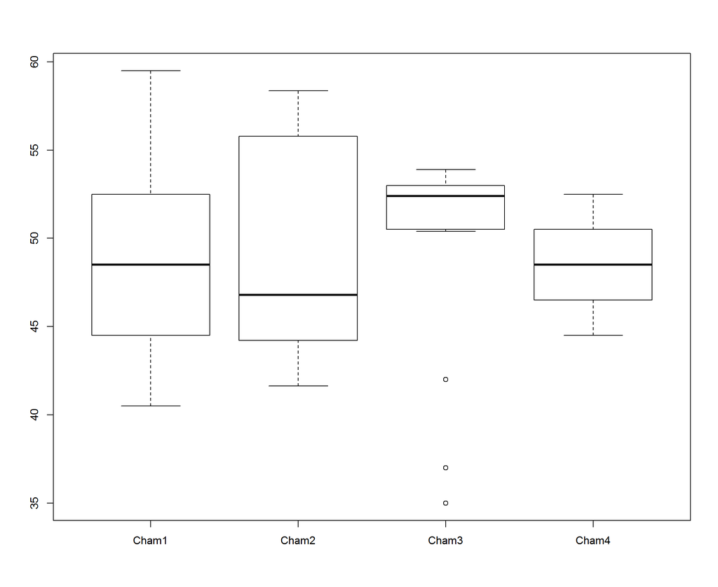

a) Complete o quadro das estatísticas descritivas destes dados. b) Compare as distribuições quanto à simetria com base nos gráficos acima. c) Que chaminé apresenta maior variação relativa? Analise criticamente sua resposta. d) As estatísticas calculadas podem ser utilizadas para descrever o comportamento dos dados?

\newpage

### Resposta letra a)

```r
tb <- fdt(LQED1)
sumdf <- sapply(LQED1, summary)
sumdf <- round(sumdf,1)
sumdf <- data.frame(sumdf)
sddf <- sapply(LQED1, sd)
stddev <- round(sddf,1)
sd <- data.frame(rbind(stddev))
resumo <- rbind(sumdf, sd)
knitr::kable(resumo, align = 'c')
```

|  | Cham1 | Cham2 | Cham3 | Cham4 |
| --- | --- | --- | --- | --- |
| Min. | 40.5 | 41.6 | 35.0 | 44.5 |
| 1st Qu. | 44.5 | 44.2 | 50.5 | 46.5 |
| Median | 48.5 | 46.8 | 52.4 | 48.5 |
| Mean | 48.7 | 49.8 | 49.9 | 48.5 |
| 3rd Qu. | 52.5 | 55.8 | 53.0 | 50.5 |
| Max. | 59.5 | 58.4 | 53.9 | 52.5 |
| stddev | 5.4 | 6.3 | 5.9 | 2.5 |

### Resposta letra b)

**Plotando os histogramas**

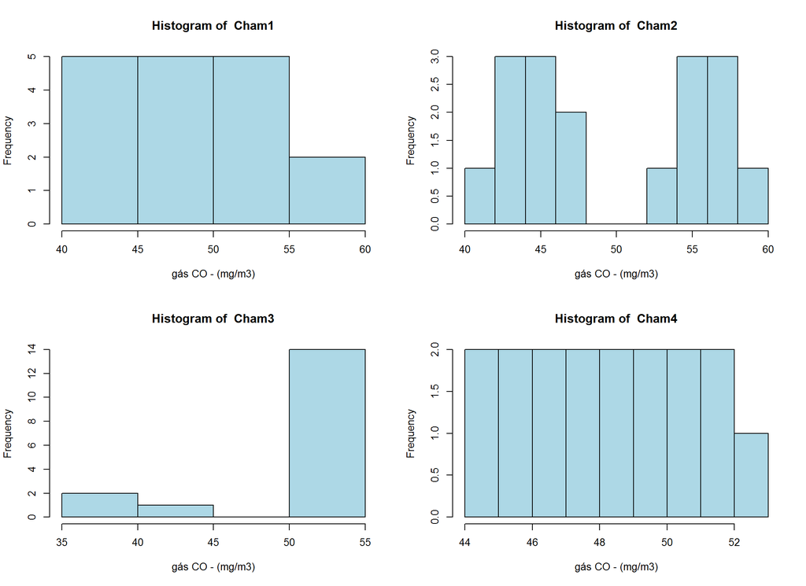

```r
par(mfrow = c(2,2))
gr2 <- sapply(X = c("Cham1","Cham2","Cham3","Cham4"), FUN=function(s) {
        hist(LQED1[,s], xlab= c("gás CO - (mg/m3)"), main = paste("Histogram of ",s),
             col = "light blue")
        })
```

```r
Cvar <- sapply(LQED1, cv)
Coefvar <- round(Cvar,2)
kurt <- sapply(LQED1, kurtosis) # Curtose
kurt <- round(kurt,2)
skwns <- sapply(LQED1, skewness) # Assimetria
skwns <- round(skwns,2)
percentl <- sapply(LQED1, quantile)
percentl <- round(percentl,2)
otprm <- rbind(Coefvar, kurt, skwns, percentl)
resumo <- rbind(otprm, make.row.names = TRUE, stringsAsFactors=
                default.stringsAsFactors())
knitr::kable(resumo, align = 'c')
```

|  | Cham1 | Cham2 | Cham3 | Cham4 |
| --- | --- | --- | --- | --- |
| Coefvar | 11.07 | 12.71 | 11.84 | 5.21 |
| kurt | 2.17 | 1.26 | 4.43 | 1.79 |
| skwns | 0.24 | 0.08 | -1.73 | 0.00 |
| 0% | 40.50 | 41.64 | 35.00 | 44.50 |
| 25% | 44.50 | 44.21 | 50.50 | 46.50 |
| 50% | 48.50 | 46.79 | 52.40 | 48.50 |
| 75% | 52.50 | 55.79 | 53.00 | 50.50 |
| 100% | 59.50 | 58.36 | 53.90 | 52.50 |
| make.row.names | 1.00 | 1.00 | 1.00 | 1.00 |
| stringsAsFactors | 1.00 | 1.00 | 1.00 | 1.00 |